# REBER Grammar with RNN

In this workbook, we are going to set-up multiple Recurrent Neural Network to test them using as test [Reber's grammar](https://www.willamette.edu/~gorr/classes/cs449/reber.html) words.

## What is a Reber Word ?

A Reber word is a word following the Reber's grammar. The grammar is based on the following graph:

[figure not shown]

The word must start with B, then it can be either T or P and so on until it reaches E. To prepare datas for this, we are going to use a OneHotEncoder to have 7 inputs, n timesteps (depending on the length of the word) and k batches. To generate it, I use the algorith from [this site](http://christianherta.de/lehre/dataScience/machineLearning/neuralNetworks/reberGrammar.php) but slightly modified to be able to validate also embedded Word

The Embedded version of the Reber Grammar using the following graph :

[figure not shown]

Our objective will be to classify real/fake Embedded Word. Due to current technologies, we will focus on Embedded Word (both system tried below with Simple Reber Word reaches 100% success and cannot be compared)

```python
import numpy as np
import matplotlib.pyplot as plt
import time
import seaborn as sns
import random

import create_dataset as reber

from keras.datasets import imdb
from keras.models import Sequential, load_model
from keras.layers import Dense
from keras.layers import LSTM, SimpleRNN, GRU
from keras.layers.embeddings import Embedding
from keras.preprocessing import sequence
from keras.callbacks import ModelCheckpoint, EarlyStopping

np.set_printoptions(precision=3)
np.set_printoptions(suppress=True)

%matplotlib inline
```

## Preparation of datas

For the OneHotEncoder, the chain 'BTSXPVE' will be used. We can now try only 1 example to check the output

```python
x, y = reber.get_one_embedded_example(minLength=10)
print(reber.sequenceToWord(x))
print(x[0], y[0])
```

```
BPBPTTVPXTVPXTVPXVVEP
[ 1.  0.  0.  0.  0.  0.  0.] [ 0.  1.  0.  0.  1.  0.  0.]
```

*y* is the possible outcome for a given input. That means B ([ 1. 0. 0. 0. 0. 0. 0.]) can be followed by T or P ([ 0. 1. 0. 0. 1. 0. 0.]).

Now we can generate words and set some of them wrong by changing random letter by another one.

```python
def set_wrong(good_seq):
    index = np.random.randint(len(good_seq))
    letter = reber.sequenceToWord([good_seq[index]])
    new_letter = random.choice(list(set("BTSXPVE") - set(letter)))
    bad_seq = good_seq.copy()
    bad_seq[index] = np.array(reber.get_char_one_hot(new_letter)[0])
    return bad_seq
```

So we have the first "problem" now, the length of the string is variable. So when we are going to generate our test/train datas, we will have to pad them to the same length (whiwh will be equalt to the longest word). This is done by using **sequence.pad_sequences** for Keras Library. The padding will be done as "post" to improve accuracy. Using a "pre" padding reduce accuracy because the cell doesn't know how many times it will receive 0 instead of "E"

```python
X_train, y_train = [], []
X_test, y_test = [], []
X_eval, y_eval = [], []
y_possible = []

maxlen = 0
min_length = 5
random_state = 42

for i in range(1024):
    x, y = reber.get_one_embedded_example(min_length)
    X_train.append(x)
    y_train.append(1)
    maxlen = max(maxlen, len(x))

for i in range(1024):
    x, y = reber.get_one_embedded_example(min_length)
    x = set_wrong(x)
    X_train.append(x)
    y_train.append(0)
    maxlen = max(maxlen, len(x))

for i in range(128):
    x, y = reber.get_one_embedded_example(min_length)
    X_test.append(x)
    y_test.append(1)
    maxlen = max(maxlen, len(x))

for i in range(128):
    x, y = reber.get_one_embedded_example(min_length)
    x = set_wrong(x)
    X_test.append(x)
    y_test.append(0)
    maxlen = max(maxlen, len(x))

for i in range(128):
    x, y = reber.get_one_embedded_example(min_length)
    X_eval.append(x)
    y_eval.append(1)
    maxlen = max(maxlen, len(x))

for i in range(128):
    x, y = reber.get_one_embedded_example(min_length)
    x = set_wrong(x)
    X_eval.append(x)
    y_eval.append(0)
    maxlen = max(maxlen, len(x))

X_train = np.array(X_train)
y_train = np.array(y_train)
X_test = np.array(X_test)
y_test = np.array(y_test)
X_eval = np.array(X_eval)
y_eval = np.array(y_eval)

from sklearn.utils import shuffle
X_train, y_train = shuffle(X_train, y_train, random_state=random_state)
X_test, y_test = shuffle(X_test, y_test, random_state=random_state)
X_eval, y_eval = shuffle(X_eval, y_eval, random_state=random_state)

X_train = sequence.pad_sequences(X_train, maxlen=maxlen, padding='post', truncating='post')
X_test = sequence.pad_sequences(X_test, maxlen=maxlen, padding='post', truncating='post')
X_eval = sequence.pad_sequences(X_eval, maxlen=maxlen, padding='post', truncating='post')

print(X_train.shape)
print(y_train.shape)
print(X_test.shape)
print(y_test.shape)
```

```
(2048, 42, 7)
(2048,)
(256, 42, 7)
(256,)
```

So now we have 2048 strings for training, 256 for test and 256 for evaluation at the final end. We can now set-up our model.

## Test of RNNs

[figure not shown]

```python
nb_unit = 7
inp_shape = (maxlen, 7)
loss_ = "binary_crossentropy"
metrics_ = "accuracy"
optimizer_ = "Adam"
nb_epoch = 250
batch_size = 64
```

### LSTM

The first model we will setup is an **LSTM** which means **L**ong **S**hort-**T**erm **M**emory. The principle is quite complex but very powerfull for long sequences inputs (because there is less issues with Vanishing Gradient Problem) or long term memory (You can refer to [this link](http://colah.github.io/posts/2015-08-Understanding-LSTMs/) for more informations)

LSTM is widely for speech recognition, Natural Language processing, Sentiment Analysis.

```python
model = Sequential()

model.add(LSTM(units=nb_unit, input_shape=inp_shape, return_sequences=True))
model.add(LSTM(units=nb_unit, input_shape=inp_shape))
model.add(Dense(1, activation='sigmoid'))

model.compile(loss=loss_,
              optimizer=optimizer_,
              metrics=[metrics_])

early = EarlyStopping(
    monitor='loss',
    min_delta=0,
    patience=10,
    verbose=1,
    mode='auto')
```

Pay attention to have words of around 38-42 characters long. This reveal the différence between SRNN and LSTM/GRU

```python
print("Inputs: {}".format(model.input_shape))
print("Outputs: {}".format(model.output_shape))
print("Actual input: {}".format(X_train.shape))
print("Actual output: {}".format(y_train.shape))
```

```
Inputs: (None, 42, 7)
Outputs: (None, 1)
Actual input: (2048, 42, 7)
Actual output: (2048,)
```

```python
start = time.time()
history = model.fit(X_train, y_train,
                    validation_data=(X_test, y_test),
                    epochs=nb_epoch,
                    batch_size=batch_size,
                    verbose=2,
                    callbacks = [early])
stop = time.time()
t1 = stop-start
print(model.summary())
print("Training time : {}s".format(t1))
LSTM_steps = len(history.history["acc"])
```

```
Train on 2048 samples, validate on 256 samples
 - 4s - loss: 0.6933 - acc: 0.5000 - val_loss: 0.6931 - val_acc: 0.5000
 - 3s - loss: 0.6932 - acc: 0.5015 - val_loss: 0.6931 - val_acc: 0.5195
 - 3s - loss: 0.6932 - acc: 0.5005 - val_loss: 0.6931 - val_acc: 0.5078
 - 3s - loss: 0.6932 - acc: 0.5029 - val_loss: 0.6931 - val_acc: 0.4844
 - 3s - loss: 0.6932 - acc: 0.4995 - val_loss: 0.6931 - val_acc: 0.5000
 - 3s - loss: 0.6933 - acc: 0.5000 - val_loss: 0.6931 - val_acc: 0.5000
 - 3s - loss: 0.6932 - acc: 0.4839 - val_loss: 0.6931 - val_acc: 0.5156
 - 3s - loss: 0.6932 - acc: 0.4980 - val_loss: 0.6931 - val_acc: 0.5352
 - 3s - loss: 0.6930 - acc: 0.5156 - val_loss: 0.6931 - val_acc: 0.4570
 - 3s - loss: 0.6926 - acc: 0.5195 - val_loss: 0.6940 - val_acc: 0.4727
 - 3s - loss: 0.6926 - acc: 0.5137 - val_loss: 0.6948 - val_acc: 0.5000
 - 3s - loss: 0.6914 - acc: 0.5337 - val_loss: 0.6953 - val_acc: 0.4766
 - 3s - loss: 0.6890 - acc: 0.5337 - val_loss: 0.6969 - val_acc: 0.4453
 - 3s - loss: 0.6883 - acc: 0.5435 - val_loss: 0.6913 - val_acc: 0.5312
 - 3s - loss: 0.6837 - acc: 0.5518 - val_loss: 0.6901 - val_acc: 0.5273
 - 3s - loss: 0.6826 - acc: 0.5537 - val_loss: 0.6911 - val_acc: 0.4961
 - 3s - loss: 0.6780 - acc: 0.5625 - val_loss: 0.6855 - val_acc: 0.5508
 - 3s - loss: 0.6732 - acc: 0.5649 - val_loss: 0.6796 - val_acc: 0.5547
 - 3s - loss: 0.6654 - acc: 0.5825 - val_loss: 0.6717 - val_acc: 0.5859
 - 3s - loss: 0.6572 - acc: 0.6040 - val_loss: 0.6564 - val_acc: 0.6016
 - 3s - loss: 0.6367 - acc: 0.6011 - val_loss: 0.6424 - val_acc: 0.6016
 - 3s - loss: 0.6234 - acc: 0.6250 - val_loss: 0.6254 - val_acc: 0.6094
 - 3s - loss: 0.6046 - acc: 0.6323 - val_loss: 0.6619 - val_acc: 0.5742
 - 3s - loss: 0.5983 - acc: 0.6509 - val_loss: 0.6080 - val_acc: 0.6367
 - 3s - loss: 0.5789 - acc: 0.6699 - val_loss: 0.5885 - val_acc: 0.6719
 - 3s - loss: 0.5536 - acc: 0.6934 - val_loss: 0.5548 - val_acc: 0.6836
 - 3s - loss: 0.6210 - acc: 0.6362 - val_loss: 0.6634 - val_acc: 0.6094
 - 3s - loss: 0.6052 - acc: 0.6499 - val_loss: 0.5627 - val_acc: 0.6758
 - 3s - loss: 0.5411 - acc: 0.7090 - val_loss: 0.5785 - val_acc: 0.6680
 - 3s - loss: 0.5659 - acc: 0.7051 - val_loss: 0.5483 - val_acc: 0.6914
 - 3s - loss: 0.5931 - acc: 0.6812 - val_loss: 0.6537 - val_acc: 0.5781
 - 3s - loss: 0.5978 - acc: 0.6753 - val_loss: 0.6332 - val_acc: 0.6406
 - 3s - loss: 0.5722 - acc: 0.6924 - val_loss: 0.6101 - val_acc: 0.6562
 - 3s - loss: 0.5414 - acc: 0.7256 - val_loss: 0.5651 - val_acc: 0.7031
 - 3s - loss: 0.5216 - acc: 0.7344 - val_loss: 0.5557 - val_acc: 0.6992
 - 3s - loss: 0.5179 - acc: 0.7363 - val_loss: 0.5426 - val_acc: 0.7305
 - 3s - loss: 0.4806 - acc: 0.7627 - val_loss: 0.4933 - val_acc: 0.7695
 - 3s - loss: 0.4621 - acc: 0.7827 - val_loss: 0.4899 - val_acc: 0.7734
 - 3s - loss: 0.4403 - acc: 0.8018 - val_loss: 0.4526 - val_acc: 0.7891
```

[output cut: 110 more lines]

```
_________________________________________________________________
Layer (type)                 Output Shape              Param #
=================================================================
lstm_9 (LSTM)                (None, 42, 7)             420
_________________________________________________________________
lstm_10 (LSTM)               (None, 7)                 420
_________________________________________________________________
dense_5 (Dense)              (None, 1)                 8
=================================================================
Total params: 848
Trainable params: 848
Non-trainable params: 0
_________________________________________________________________
None
Training time : 449.2601935863495s
```

## Simple RNN

Using the same code, we can train the standard RNN.

[figure not shown]

This allows a "short term memory". It creates a kind of hysteresis used as memory

```python
model2 = Sequential()
model2.add(SimpleRNN(units=nb_unit, input_shape=inp_shape, return_sequences=True))
model2.add(SimpleRNN(units=nb_unit, input_shape=inp_shape))
model2.add(Dense(1, activation='sigmoid'))
model2.compile(loss=loss_,
              optimizer=optimizer_,
              metrics=[metrics_])
```

```python
start = time.time()
history2 = model2.fit(X_train, y_train,
                    validation_data=(X_test, y_test),
                    epochs=nb_epoch,
                    batch_size=batch_size,
                    verbose=2,
                    callbacks = [early])
stop = time.time()
t2 = stop-start
print(model2.summary(), end=" ")
print("Training time : {}s".format(t2))
SRNN_steps = len(history2.history["acc"])
```

```
Train on 2048 samples, validate on 256 samples
 - 2s - loss: 0.7319 - acc: 0.4985 - val_loss: 0.6996 - val_acc: 0.5156
 - 1s - loss: 0.6991 - acc: 0.5010 - val_loss: 0.6915 - val_acc: 0.5469
 - 1s - loss: 0.6939 - acc: 0.5083 - val_loss: 0.6893 - val_acc: 0.5273
 - 1s - loss: 0.6921 - acc: 0.5269 - val_loss: 0.6883 - val_acc: 0.5352
 - 1s - loss: 0.6904 - acc: 0.5151 - val_loss: 0.6869 - val_acc: 0.5312
 - 1s - loss: 0.6873 - acc: 0.5376 - val_loss: 0.6843 - val_acc: 0.5234
 - 1s - loss: 0.6773 - acc: 0.5874 - val_loss: 0.6718 - val_acc: 0.5938
 - 1s - loss: 0.6563 - acc: 0.6284 - val_loss: 0.6593 - val_acc: 0.6133
 - 1s - loss: 0.6380 - acc: 0.6475 - val_loss: 0.6505 - val_acc: 0.6172
 - 1s - loss: 0.6295 - acc: 0.6475 - val_loss: 0.6412 - val_acc: 0.6250
 - 1s - loss: 0.6214 - acc: 0.6567 - val_loss: 0.6351 - val_acc: 0.6172
 - 1s - loss: 0.6220 - acc: 0.6489 - val_loss: 0.6350 - val_acc: 0.6289
 - 1s - loss: 0.6226 - acc: 0.6460 - val_loss: 0.6385 - val_acc: 0.6250
 - 1s - loss: 0.6136 - acc: 0.6470 - val_loss: 0.6273 - val_acc: 0.6328
 - 1s - loss: 0.6178 - acc: 0.6455 - val_loss: 0.6234 - val_acc: 0.6406
 - 1s - loss: 0.6060 - acc: 0.6504 - val_loss: 0.5915 - val_acc: 0.6484
 - 1s - loss: 0.6072 - acc: 0.6450 - val_loss: 0.6104 - val_acc: 0.6250
 - 1s - loss: 0.5969 - acc: 0.6475 - val_loss: 0.5994 - val_acc: 0.6680
 - 1s - loss: 0.5864 - acc: 0.6655 - val_loss: 0.5751 - val_acc: 0.6719
 - 1s - loss: 0.5812 - acc: 0.6792 - val_loss: 0.5779 - val_acc: 0.6914
 - 1s - loss: 0.5867 - acc: 0.6860 - val_loss: 0.5577 - val_acc: 0.6914
 - 1s - loss: 0.5786 - acc: 0.6895 - val_loss: 0.5768 - val_acc: 0.6953
 - 1s - loss: 0.5900 - acc: 0.6865 - val_loss: 0.5758 - val_acc: 0.6914
 - 1s - loss: 0.5758 - acc: 0.6968 - val_loss: 0.5657 - val_acc: 0.7109
 - 1s - loss: 0.5731 - acc: 0.6997 - val_loss: 0.5654 - val_acc: 0.7422
 - 1s - loss: 0.5680 - acc: 0.7109 - val_loss: 0.5391 - val_acc: 0.7305
 - 1s - loss: 0.5606 - acc: 0.7139 - val_loss: 0.5441 - val_acc: 0.7422
 - 1s - loss: 0.5577 - acc: 0.7222 - val_loss: 0.5338 - val_acc: 0.7461
 - 1s - loss: 0.5506 - acc: 0.7305 - val_loss: 0.5356 - val_acc: 0.7266
 - 1s - loss: 0.5532 - acc: 0.7271 - val_loss: 0.5453 - val_acc: 0.7695
 - 1s - loss: 0.5502 - acc: 0.7363 - val_loss: 0.5273 - val_acc: 0.7617
 - 1s - loss: 0.5387 - acc: 0.7451 - val_loss: 0.5073 - val_acc: 0.7578
 - 1s - loss: 0.5436 - acc: 0.7339 - val_loss: 0.5347 - val_acc: 0.7539
 - 1s - loss: 0.5378 - acc: 0.7466 - val_loss: 0.5045 - val_acc: 0.7930
 - 1s - loss: 0.5305 - acc: 0.7490 - val_loss: 0.5077 - val_acc: 0.7500
 - 1s - loss: 0.5348 - acc: 0.7432 - val_loss: 0.4987 - val_acc: 0.7891
 - 1s - loss: 0.5288 - acc: 0.7476 - val_loss: 0.5188 - val_acc: 0.7578
 - 1s - loss: 0.5242 - acc: 0.7471 - val_loss: 0.4937 - val_acc: 0.7812
 - 1s - loss: 0.5274 - acc: 0.7510 - val_loss: 0.5134 - val_acc: 0.7578
```

[output cut: 100 more lines]

```
Epoch 00139: early stopping
_________________________________________________________________
Layer (type)                 Output Shape              Param #
=================================================================
simple_rnn_1 (SimpleRNN)     (None, 42, 7)             105
_________________________________________________________________
simple_rnn_2 (SimpleRNN)     (None, 7)                 105
_________________________________________________________________
dense_6 (Dense)              (None, 1)                 8
=================================================================
Total params: 218
Trainable params: 218
Non-trainable params: 0
_________________________________________________________________
None Training time : 103.32829141616821s
```

## GRU

Finally, we can train a **GRU** (**G**ated **R**ecurrent **U**nits). It's a simplification of LSTMs. They also have a memory mechanism but with less parameters. As a result they are faster to train. You can find differences on [this topic](https://datascience.stackexchange.com/questions/14581/what-is-difference-between-gru-and-lstm)

```python
model3 = Sequential()
model3.add(GRU(units=nb_unit, input_shape=inp_shape, return_sequences=True))
model3.add(GRU(units=nb_unit, input_shape=inp_shape))
model3.add(Dense(1, activation='sigmoid'))
model3.compile(loss=loss_,
              optimizer=optimizer_,
              metrics=[metrics_])
```

```python
start = time.time()
history3 = model3.fit(X_train, y_train,
                    validation_data=(X_test, y_test),
                    epochs=nb_epoch,
                    batch_size=batch_size,
                    verbose=2,
                    callbacks = [early])
stop = time.time()
t3 = stop-start
print(model3.summary(), end=" ")
print("Training time : {}s".format(t3))
GRU_steps = len(history3.history["acc"])
```

```
Train on 2048 samples, validate on 256 samples
 - 4s - loss: 0.6932 - acc: 0.4990 - val_loss: 0.6931 - val_acc: 0.5000
 - 2s - loss: 0.6933 - acc: 0.4888 - val_loss: 0.6931 - val_acc: 0.5000
 - 2s - loss: 0.6932 - acc: 0.4888 - val_loss: 0.6931 - val_acc: 0.5000
 - 2s - loss: 0.6932 - acc: 0.4971 - val_loss: 0.6931 - val_acc: 0.5000
 - 2s - loss: 0.6931 - acc: 0.4883 - val_loss: 0.6931 - val_acc: 0.5000
 - 2s - loss: 0.6932 - acc: 0.4927 - val_loss: 0.6931 - val_acc: 0.5000
 - 2s - loss: 0.6931 - acc: 0.4834 - val_loss: 0.6931 - val_acc: 0.5000
 - 2s - loss: 0.6933 - acc: 0.5000 - val_loss: 0.6931 - val_acc: 0.5000
 - 2s - loss: 0.6931 - acc: 0.4712 - val_loss: 0.6931 - val_acc: 0.5039
 - 2s - loss: 0.6931 - acc: 0.5010 - val_loss: 0.6931 - val_acc: 0.5039
 - 2s - loss: 0.6931 - acc: 0.4893 - val_loss: 0.6931 - val_acc: 0.5000
 - 2s - loss: 0.6932 - acc: 0.4990 - val_loss: 0.6931 - val_acc: 0.5000
 - 2s - loss: 0.6931 - acc: 0.5005 - val_loss: 0.6931 - val_acc: 0.5000
 - 2s - loss: 0.6931 - acc: 0.5000 - val_loss: 0.6932 - val_acc: 0.5000
 - 2s - loss: 0.6931 - acc: 0.5000 - val_loss: 0.6931 - val_acc: 0.5000
 - 2s - loss: 0.6930 - acc: 0.4961 - val_loss: 0.6931 - val_acc: 0.5000
 - 2s - loss: 0.6930 - acc: 0.4858 - val_loss: 0.6930 - val_acc: 0.5000
 - 2s - loss: 0.6930 - acc: 0.4961 - val_loss: 0.6930 - val_acc: 0.5078
 - 2s - loss: 0.6929 - acc: 0.4956 - val_loss: 0.6926 - val_acc: 0.4844
 - 2s - loss: 0.6931 - acc: 0.4907 - val_loss: 0.6922 - val_acc: 0.5000
 - 2s - loss: 0.6929 - acc: 0.4893 - val_loss: 0.6924 - val_acc: 0.5156
 - 2s - loss: 0.6929 - acc: 0.4946 - val_loss: 0.6924 - val_acc: 0.5273
 - 2s - loss: 0.6927 - acc: 0.5005 - val_loss: 0.6923 - val_acc: 0.5078
 - 2s - loss: 0.6926 - acc: 0.5034 - val_loss: 0.6919 - val_acc: 0.5156
 - 2s - loss: 0.6928 - acc: 0.4946 - val_loss: 0.6918 - val_acc: 0.4922
 - 2s - loss: 0.6927 - acc: 0.4917 - val_loss: 0.6920 - val_acc: 0.5117
 - 2s - loss: 0.6929 - acc: 0.4980 - val_loss: 0.6919 - val_acc: 0.5000
 - 2s - loss: 0.6925 - acc: 0.4976 - val_loss: 0.6919 - val_acc: 0.4961
 - 2s - loss: 0.6929 - acc: 0.4888 - val_loss: 0.6919 - val_acc: 0.4922
 - 2s - loss: 0.6931 - acc: 0.5059 - val_loss: 0.6921 - val_acc: 0.5117
 - 2s - loss: 0.6927 - acc: 0.4980 - val_loss: 0.6921 - val_acc: 0.5000
 - 2s - loss: 0.6926 - acc: 0.4937 - val_loss: 0.6920 - val_acc: 0.5000
 - 2s - loss: 0.6926 - acc: 0.4976 - val_loss: 0.6919 - val_acc: 0.5273
 - 2s - loss: 0.6925 - acc: 0.5068 - val_loss: 0.6918 - val_acc: 0.4883
 - 2s - loss: 0.6926 - acc: 0.5029 - val_loss: 0.6918 - val_acc: 0.5078
 - 2s - loss: 0.6927 - acc: 0.5010 - val_loss: 0.6920 - val_acc: 0.5000
 - 2s - loss: 0.6924 - acc: 0.5029 - val_loss: 0.6921 - val_acc: 0.5117
 - 2s - loss: 0.6928 - acc: 0.5000 - val_loss: 0.6922 - val_acc: 0.5117
 - 2s - loss: 0.6925 - acc: 0.5020 - val_loss: 0.6921 - val_acc: 0.5273
```

[output cut: 153 more lines]

```
Epoch 00192: early stopping
_________________________________________________________________
Layer (type)                 Output Shape              Param #
=================================================================
gru_1 (GRU)                  (None, 42, 7)             315
_________________________________________________________________
gru_2 (GRU)                  (None, 7)                 315
_________________________________________________________________
dense_7 (Dense)              (None, 1)                 8
=================================================================
Total params: 638
Trainable params: 638
Non-trainable params: 0
_________________________________________________________________
None Training time : 459.7016022205353s
```

## Evaluation

We can first check the time used to train them and the number of epochs required before EarlyStop

```python
print("LSTM :       {:.2f}s - {} epoch".format(t1, LSTM_steps))
print("Simple RNN : {:.2f}s - {} epoch".format(t2, SRNN_steps))
print("GRU :        {:.2f}s - {} epoch".format(t3, GRU_steps))
```

```
LSTM :       449.26s - 148 epoch
Simple RNN : 103.33s - 139 epoch
GRU :        459.70s - 192 epoch
```

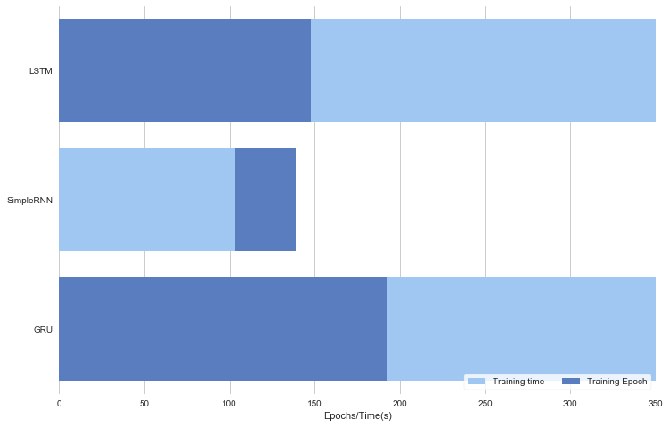

```python
sns.set(style="whitegrid")

f, ax = plt.subplots(figsize=(12, 8))

sns.set_color_codes("pastel")
sns.barplot(x=[t1, 0, t3] , y=["LSTM", "SimpleRNN", "GRU"], label="Training time", color="b")

sns.set_color_codes("muted")
sns.barplot(x=[LSTM_steps, SRNN_steps, GRU_steps], y=["LSTM", "SimpleRNN", "GRU"], label="Training Epoch", color="b")

# just because SRNN step > time
sns.set_color_codes("pastel")
sns.barplot(x=[0, t2, 0] , y=["LSTM", "SimpleRNN", "GRU"], color="b")

# Add a legend and informative axis label
ax.legend(ncol=2, loc="lower right", frameon=True)
ax.set(xlim=(0, 350), ylabel="",
       xlabel="Epochs/Time(s)")
sns.despine(left=True, bottom=True)
plt.savefig("barplot.png")
plt.show()
```

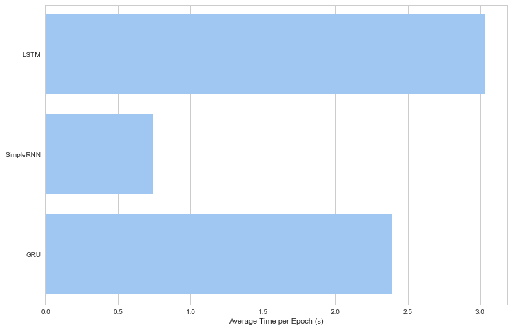

```python
sns.set(style="whitegrid")

f, ax = plt.subplots(figsize=(12, 8))

sns.set_color_codes("pastel")
sns.barplot(x=[t1/LSTM_steps, t2/SRNN_steps, t3/GRU_steps] , y=["LSTM", "SimpleRNN", "GRU"], color="b")

# ax.set(xlim=(0, 350), ylabel="", xlabel="Epochs/Time(s)")
# sns.despine(left=True, bottom=True)
plt.xlabel("Average Time per Epoch (s)")
plt.savefig("barplot_time.png")
plt.show()
```

```
dict_keys(['val_loss', 'val_acc', 'loss', 'acc'])
```

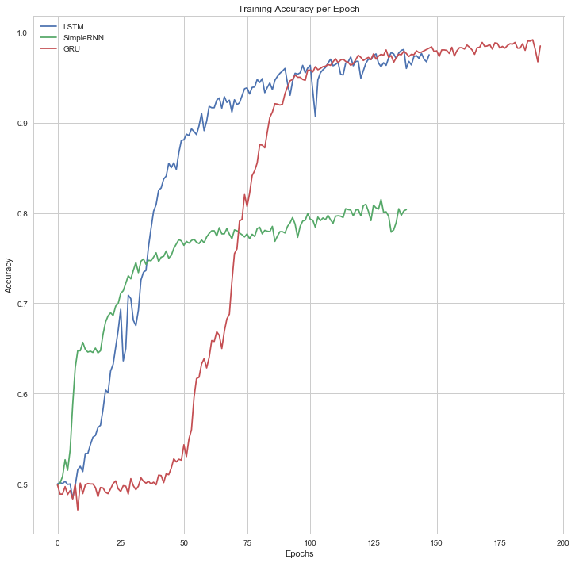

```python
print(history.history.keys())
key_ = "acc" # list(history.history.keys())[3]
plt.figure(figsize=(12, 12))
plt.plot(history.history[key_], label="LSTM")
plt.plot(history2.history[key_], label="SimpleRNN")
plt.plot(history3.history[key_], label="GRU")
plt.legend()
plt.ylabel("Accuracy")
plt.xlabel("Epochs")
plt.title("Training Accuracy per Epoch")
plt.savefig("accuracy.png")
plt.show()
```

```
dict_keys(['val_loss', 'val_acc', 'loss', 'acc'])
```

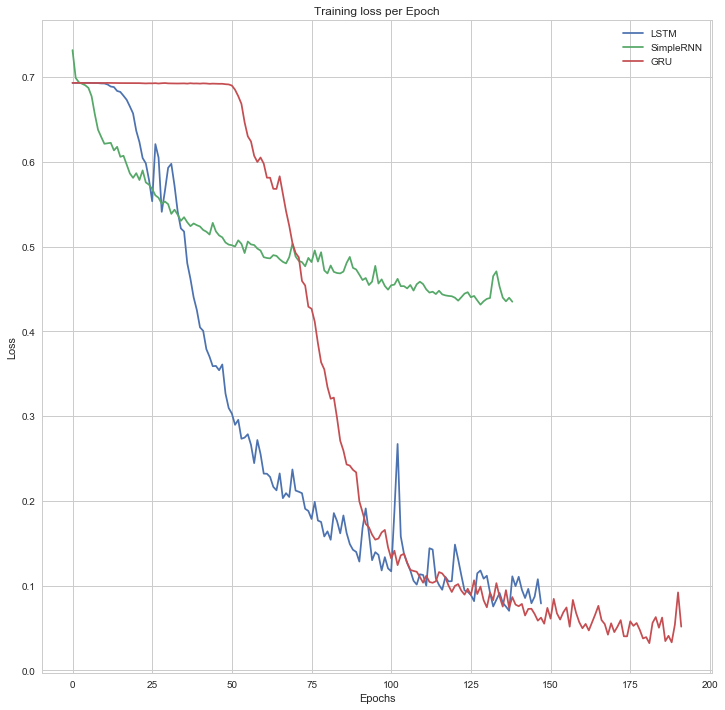

```python
print(history.history.keys())
key_ = "loss" # list(history.history.keys())[3]
plt.figure(figsize=(12, 12))
plt.plot(history.history[key_], label="LSTM")
plt.plot(history2.history[key_], label="SimpleRNN")
plt.plot(history3.history[key_], label="GRU")
plt.legend()
plt.ylabel("Loss")
plt.xlabel("Epochs")
plt.title("Training loss per Epoch")
plt.savefig("loss.png")
plt.show()
```

```python
from sklearn.metrics import accuracy_score, confusion_matrix, precision_score, recall_score, f1_score, log_loss
```

```python
y_pred = model.predict(X_eval)

y_pred_floor= np.around(y_pred)

print(accuracy_score(y_eval, y_pred_floor))
print(confusion_matrix(y_eval, y_pred_floor))
print(precision_score(y_eval, y_pred_floor))
print(recall_score(y_eval, y_pred_floor))
print(f1_score(y_eval, y_pred_floor))
print(log_loss(y_eval, y_pred))
```

```
0.96875
[[122   6]
 [  2 126]]
0.954545454545
0.984375
0.969230769231
0.0964980389554
```

```python
y_pred = model2.predict(X_eval)

y_pred_floor= np.around(y_pred)

print(accuracy_score(y_eval, y_pred_floor))
print(confusion_matrix(y_eval, y_pred_floor))
print(precision_score(y_eval, y_pred_floor))
print(recall_score(y_eval, y_pred_floor))
print(f1_score(y_eval, y_pred_floor))
print(log_loss(y_eval, y_pred))
```

```
0.7578125
[[100  28]
 [ 34  94]]
0.770491803279
0.734375
0.752
0.48050892388
```

```python
y_pred = model3.predict(X_eval)

y_pred_floor= np.around(y_pred)

print(accuracy_score(y_eval, y_pred_floor))
print(confusion_matrix(y_eval, y_pred_floor))
print(precision_score(y_eval, y_pred_floor))
print(recall_score(y_eval, y_pred_floor))
print(f1_score(y_eval, y_pred_floor))
print(log_loss(y_eval, y_pred))
```

```
0.984375
[[125   3]
 [  1 127]]
0.976923076923
0.9921875
0.984496124031
0.0586241011113
```

## Conclusion

In this workbook, we started to go through RNN. We trained 3 models to classify either a word is or isn't following Reber's rule. Further topolies can be used to improve performances (more layers, fully connected layer?).